# COVID19 Mortality rate prediction. IML ’20 Homework 4. - Appendix

Łukasz Grad

Data source: https://github.com/beoutbreakprepared/nCoV2019/blob/master/latest_data/latestdata.csv

```r
covid %>% head()
```

| ID | age | sex | city | province | country | wuhan(0)_not_wuhan(1) | latitude | longitude | geo_resolution | date_onset_symptoms | date_admission_hospital | date_confirmation | symptoms | lives_in_Wuhan | travel_history_dates | travel_history_location | reported_market_exposure | additional_information | chronic_disease_binary | chronic_disease | source | sequence_available | outcome | date_death_or_discharge | notes_for_discussion | location | admin3 | admin2 | admin1 | … |
| --- | --- | --- | --- | --- | --- | --- | --- | --- | --- | --- | --- | --- | --- | --- | --- | --- | --- | --- | --- | --- | --- | --- | --- | --- | --- | --- | --- | --- | --- | --- |
| NA | 1 | female | Calapan | Oriental Mindoro | Philippines | NA | NA | NA | NA | NA | NA | 26.03.2020 | NA | NA | NA | NA | NA | PH990 | NA | NA | NA | NA | NA | NA | NA | NA | NA | NA | NA | … |
| NA | 55 | female | San Juan | Metro Manila | Philippines | NA | NA | NA | NA | NA | NA | 27.03.2020 | NA | NA | NA | NA | NA | PH908 | NA | NA | NA | NA | NA | NA | NA | NA | NA | NA | NA | … |
| NA | 71 | female | San Juan | Metro Manila | Philippines | NA | NA | NA | NA | NA | NA | 27.03.2020 | NA | NA | NA | NA | NA | PH909 | NA | NA | NA | NA | NA | NA | NA | NA | NA | NA | NA | … |
| NA | 68 | male | Kalibo | Aklan | Philippines | NA | NA | NA | NA | NA | NA | 27.03.2020 | NA | NA | NA | NA | NA | PH910 | NA | NA | NA | NA | NA | NA | NA | NA | NA | NA | NA | … |
| NA | 66 | female | Mandaluyong | Metro Manila | Philippines | NA | NA | NA | NA | NA | NA | 25.03.2020 | NA | NA | NA | NA | NA | PH911 | NA | NA | NA | NA | NA | NA | NA | NA | NA | NA | NA | … |
| NA | 75 | male | Olongapo | Zambales | Philippines | NA | NA | NA | NA | NA | NA | 27.03.2020 | NA | NA | NA | NA | NA | PH912 | NA | NA | NA | NA | NA | NA | NA | NA | NA | NA | NA | … |

```r
covid %>%
    summarise_all(~ mean(is.na(.)))
```

| ID | age | sex | city | province | country | wuhan(0)_not_wuhan(1) | latitude | longitude | geo_resolution | date_onset_symptoms | date_admission_hospital | date_confirmation | symptoms | lives_in_Wuhan | travel_history_dates | travel_history_location | reported_market_exposure | additional_information | chronic_disease_binary | chronic_disease | source | sequence_available | outcome | date_death_or_discharge | notes_for_discussion | location | admin3 | admin2 | admin1 | … |
| --- | --- | --- | --- | --- | --- | --- | --- | --- | --- | --- | --- | --- | --- | --- | --- | --- | --- | --- | --- | --- | --- | --- | --- | --- | --- | --- | --- | --- | --- | --- |
| 1 | 0.9551809 | 0.9426019 | 0.5132704 | 0.06493351 | 0.0002810326 | 0.7573977 | 1 | 0.9995204 | 1 | 0.9841648 | 1 | 0.005781776 | 0.9934688 | 1 | 1 | 1 | 1 | 0.968663 | 0.9993405 | 0.9992094 | 1 | 1 | 0.9962342 | 0.9981339 | 1 | 1 | 1 | 1 | 1 | … |

```r
# A tiny bit of cheating to increase positive sample size
death_vals = c('death', 'died',
               'treated in an intensive care unit (14.02.2020)',
               'critical condition, intubated as of 14.02.2020')
covid %>% filter(outcome %in% death_vals)
```

| ID | age | sex | city | province | country | wuhan(0)_not_wuhan(1) | latitude | longitude | geo_resolution | date_onset_symptoms | date_admission_hospital | date_confirmation | symptoms | lives_in_Wuhan | travel_history_dates | travel_history_location | reported_market_exposure | additional_information | chronic_disease_binary | chronic_disease | source | sequence_available | outcome | date_death_or_discharge | notes_for_discussion | location | admin3 | admin2 | admin1 | … |
| --- | --- | --- | --- | --- | --- | --- | --- | --- | --- | --- | --- | --- | --- | --- | --- | --- | --- | --- | --- | --- | --- | --- | --- | --- | --- | --- | --- | --- | --- | --- |
| NA | 71 | male | Iloilo | Iloilo | Philippines | NA | NA | NA | NA | NA | NA | 27.03.2020 | acute respiratory distress syndrome:pneumonia | NA | NA | NA | NA | PH900 | 1 | hypertension:cardiac disease | NA | NA | died | 21.03.2020 | NA | NA | NA | NA | NA | … |
| NA | 83 | male | Paranaque | Metro Manila | Philippines | NA | NA | NA | NA | NA | NA | 26.03.2020 | acute respiratory distress syndrome | NA | NA | NA | NA | PH935 | 1 | chronic kidney disease:hypertension:diabetes | NA | NA | died | 29.03.2020 | NA | NA | NA | NA | NA | … |
| NA | 60 | male | Muntinlupa | Metro Manila | Philippines | NA | NA | NA | NA | NA | NA | 25.03.2020 | acute respiratory distress syndrome:septic shock | NA | NA | NA | NA | PH1488 | NA | NA | NA | NA | died | 26.03.2020 | NA | NA | NA | NA | NA | … |
| NA | 74 | male | Quezon | Metro Manila | Philippines | NA | NA | NA | NA | NA | NA | 27.03.2020 | acute respiratory distress syndrome: pneumonia | NA | NA | NA | NA | PH1489 | 1 | diabetes:hypertension | NA | NA | died | 21.03.2020 | NA | NA | NA | NA | NA | … |
| NA | 50 | male | Pasig | Metro Manila | Philippines | NA | NA | NA | NA | NA | NA | 24.03.2020 | acute respiratory failure:pneumonia | NA | NA | NA | NA | PH540 | 1 | diabetes | NA | NA | died | 20.03.2020 | NA | NA | NA | NA | NA | … |
| NA | 89 | male | Caloocan | Metro Manila | Philippines | NA | NA | NA | NA | NA | NA | 20.03.2020 | arrhythmia:sepsis:acute respiratory distress syndrome:pneumonia:acute kidney injury | NA | NA | NA | NA | PH1372 | 1 | chronic obstructive pulmonary disease:diabetes:dyslipidemia | NA | NA | died | 28.03.2020 | NA | NA | NA | NA | NA | … |
| NA | 45 | male | Davao | Davao del Sur | Philippines | NA | NA | NA | NA | NA | NA | NA | cardiopulmonary arrest: acute respiratory distress syndrome: pneumonia: hypoxia | NA | NA | NA | NA | PH1447 | NA | NA | NA | NA | died | 23.03.2020 | NA | NA | NA | NA | NA | … |
| NA | 59 | male | Davao | Davao del Sur | Philippines | NA | NA | NA | NA | NA | NA | 23.03.2020 | acute respiratory distress syndrome:pneumonia:hypoxia | NA | NA | NA | NA | PH1446 | 1 | cardiac disease | NA | NA | died | 23.03.2020 | NA | NA | NA | NA | NA | … |
| NA | 69 | male | Quezon | Metro Manila | Philippines | NA | NA | NA | NA | NA | NA | 27.03.2020 | septic shock:pneumonia | NA | NA | NA | NA | PH1419 | 1 | hypertension:cerebrovascular accident infarct | NA | NA | died | 30.03.2020 | NA | NA | NA | NA | NA | … |
| NA | 64 | male | San Juan | Metro Manila | Philippines | NA | NA | NA | NA | NA | NA | 25.03.2020 | heart failure:pneumonia | NA | NA | NA | NA | PH676 | 1 | hypertension:diabetes:chronic kidney disease | NA | NA | died | 24.03.2020 | NA | NA | NA | NA | NA | … |

[output cut: 190 more lines]

```r
clean_string <- function(string){
    temp <- tolower(string)
    temp <- stringr::str_replace_all(temp,"[^a-zA-Z\\s]", " ")
    temp <- stringr::str_replace_all(temp,"[\\s]+", " ")
    temp <- stringr::str_split(temp, " ")[[1]]
    indexes <- which(temp == "")
    if(length(indexes) > 0){
      temp <- temp[-indexes]
    }
    return(temp)
}
```

```r
symptoms_data = lapply(covid$symptoms, clean_string)
```

```r
symptoms_all <- unlist(symptoms_data)
symptoms_all_sorted = sort(table(symptoms_all), decreasing = T)
symptoms_all_sorted[1:15]
```

```
## symptoms_all
##       fever       cough        mild    moderate        sore      throat
##        1005         556         274         215         122         120
##   pneumonia respiratory          to       acute     fatigue    headache
##         108          89          88          81          72          70
##     malaise        pain        nose
##          57          55          47
```

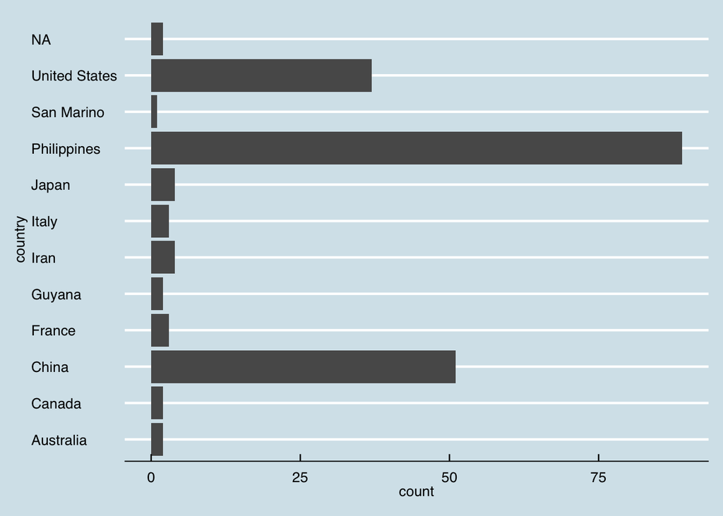

```r
covid %>%
    filter(outcome %in% death_vals) %>%
    ggplot(aes(country)) +
    geom_bar() +
    coord_flip()
```

```r
frequent_countries = c('china', 'united states', 'philippines')
frequent_symptoms = c('pneumonia|pneumonitis', 'fever',
                      'cough', 'sore throat')

covid_train = covid %>%
    mutate(
        outcome = ifelse(outcome %in% death_vals, 'dead', 'recovered'),
        country = ifelse(tolower(country) %in% frequent_countries, country, 'other'),
        in_wuhan = !as.logical(`wuhan(0)_not_wuhan(1)`),
        age = ifelse(str_detect(age, "[:digit:]{2}-[:digit:]{2}"),
                     0.5 * as.numeric(str_sub(age, 1, 2)) + 0.5 * as.numeric(str_sub(age, 3, 4)),
                     as.numeric(age)),
        sex = tolower(sex),
        chronic_disease = ifelse(is.na(chronic_disease_binary),
                                 'unknown',
                                 ifelse(chronic_disease_binary == '1', '1', '0'))
    ) %>%
    select(age, sex, country, chronic_disease, outcome, in_wuhan, symptoms) %>%
    filter(!is.na(age)) %>%
    filter(!is.na(sex))

for (symptom in frequent_symptoms) {
    covid_train[symptom] = str_detect(symptom, covid_train$symptoms)
    covid_train[symptom][is.na(covid_train[symptom])] = F
}

covid_train = covid_train %>% select(-symptoms)
covid_train = covid_train %>%
    mutate_if(is.logical, as.factor)

covid_train %>% head
```

| age | sex | country | chronic_disease | outcome | in_wuhan | pneumonia\|pneumonitis | fever | cough | sore throat |
| --- | --- | --- | --- | --- | --- | --- | --- | --- | --- |
| 1 | female | Philippines | unknown | recovered | NA | FALSE | FALSE | FALSE | FALSE |
| 55 | female | Philippines | unknown | recovered | NA | FALSE | FALSE | FALSE | FALSE |
| 71 | female | Philippines | unknown | recovered | NA | FALSE | FALSE | FALSE | FALSE |
| 68 | male | Philippines | unknown | recovered | NA | FALSE | FALSE | FALSE | FALSE |
| 66 | female | Philippines | unknown | recovered | NA | FALSE | FALSE | FALSE | FALSE |
| 75 | male | Philippines | unknown | recovered | NA | FALSE | FALSE | FALSE | FALSE |

```r
set.seed(1)
covid_train = covid_train %>% select(-in_wuhan)
covid_train = covid_train[sample(1:nrow(covid_train), size = nrow(covid_train), replace = F, ),]
```

```r
covid_train = covid_train %>%
    mutate_if(is.character, as.factor)

train_mask = caret::createDataPartition(covid_train$outcome, p = 0.7)[[1]]
data_train = covid_train[train_mask,]
data_valid = covid_train[-train_mask,]

xlevs_train = data_train %>% select(-outcome)
xlevs <- lapply(xlevs_train[,sapply(xlevs_train, is.factor), drop = F], function(j){
    levels(j)
})
```

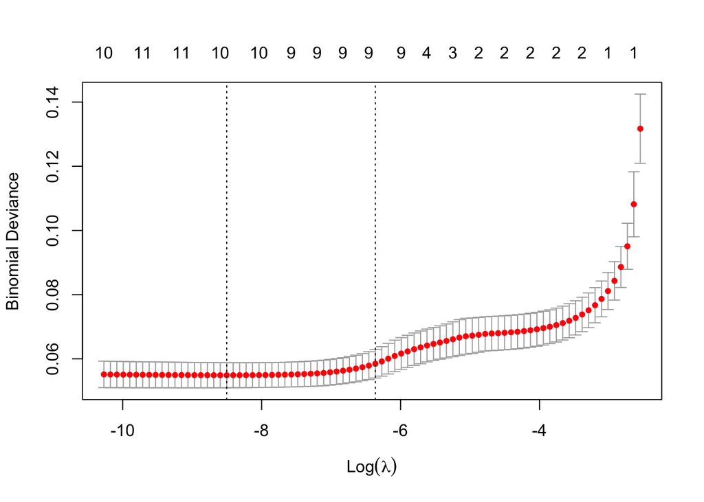

```r
pos = function(x, s, u = NULL) {
    x = ifelse(x > s, x - s, 0)
    if (!is.null(u))
        x = ifelse(x > (u - s), u - s, x)
    x
}

dtrain = model.matrix(~ age + pos(age, 50) + . - 1,
                      data = data_train %>% select(-outcome))
dvalid = model.matrix(~ age + pos(age, 50) +  . - 1,
                      data = data_valid %>% select(-outcome))
cv_glmnet = cv.glmnet(dtrain, data_train$outcome == 'dead', family = 'binomial', nfolds = 5,
                   type.measure = 'deviance', keep = TRUE)
plot(cv_glmnet)
```

```r
best_ind = which(cv_glmnet$lambda == cv_glmnet$lambda.min)
beta = cv_glmnet$glmnet.fit$beta[, best_ind]
beta
```

```
##                         age                pos(age, 50)
##                 0.061517717                 0.006752388
##                   sexfemale                     sexmale
##                 0.000000000                 0.000000000
##                countryother          countryPhilippines
##                -1.975054211                -0.254083846
##        countryUnited States            chronic_disease1
##                -3.491188832                 2.191136187
##      chronic_diseaseunknown `pneumonia|pneumonitis`TRUE
##                -3.067191211                 0.881613417
##                   feverTRUE                   coughTRUE
##                 0.822306099                -4.297450482
##           `sore throat`TRUE
##                 0.000000000
```

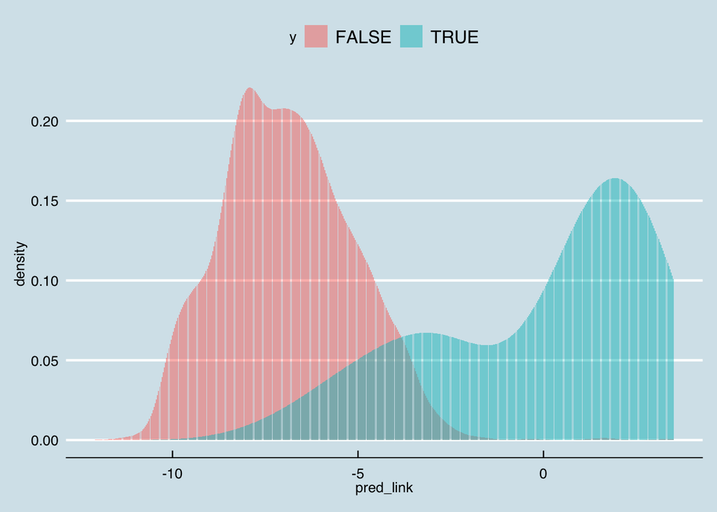

```r
pred_data = tibble(y = data_valid$outcome == 'dead',
       pred_link = predict(cv_glmnet, dvalid, type='link', s = 'lambda.min'),
       pred = predict(cv_glmnet, dvalid, type='response', s = 'lambda.min'))
pred_data %>%
    ggplot(aes(pred_link, fill = y)) +
    geom_histogram(stat = 'density', alpha = 0.5, position = 'identity')
```

```r
lrm = glm(outcome == 'dead' ~ age + sex + country +
                              fever + chronic_disease,
          family = 'binomial', data = data_train)
summary(lrm)
```

```
##
## Call:
## glm(formula = outcome == "dead" ~ age + sex + country + fever +
##     chronic_disease, family = "binomial", data = data_train)
##
## Deviance Residuals:
##     Min       1Q   Median       3Q      Max
## -2.7449  -0.0719  -0.0342  -0.0182   3.9315
##
## Coefficients:
##                        Estimate Std. Error z value Pr(>|z|)
## (Intercept)            -5.15951    1.45744  -3.540   0.0004 ***
## age                     0.07048    0.01075   6.556 5.54e-11 ***
## sexmale                 0.06674    0.31091   0.215   0.8300
## countryother           -2.29276    0.49101  -4.669 3.02e-06 ***
## countryPhilippines     -0.48997    0.37163  -1.318   0.1874
## countryUnited States   -4.27411    1.04128  -4.105 4.05e-05 ***
## feverTRUE               0.75699    0.63581   1.191   0.2338
## chronic_disease1        2.27802    1.32970   1.713   0.0867 .
## chronic_diseaseunknown -3.01280    1.30526  -2.308   0.0210 *
## ---
## Signif. codes:  0 '***' 0.001 '**' 0.01 '*' 0.05 '.' 0.1 ' ' 1
##
## (Dispersion parameter for binomial family taken to be 1)
##
##     Null deviance: 1106.0  on 8185  degrees of freedom
## Residual deviance:  422.7  on 8177  degrees of freedom
## AIC: 440.7
##
## Number of Fisher Scoring iterations: 10
```

```r
dtrain_xgb = model.matrix(~ . - 1, data = data_train %>% select(-outcome))
dvalid_xgb = model.matrix(~ . - 1, data = data_valid %>% select(-outcome))

bst  = xgboost(data = dtrain_xgb, label = ifelse(data_train$outcome == 'dead', 1, 0), max_depth = 4,
               eta = 0.3, nrounds = 35, nthread = 2, colsample_bytree = 0.5,
               objective = "binary:logistic", scale_pos_weight = 1, eval_metric = 'logloss',
               monotone_constraints = '(1, 0, 0, 0, 0, 0, 0, 0, 0, 0, 0, 0, 0, 0, 0)')
```

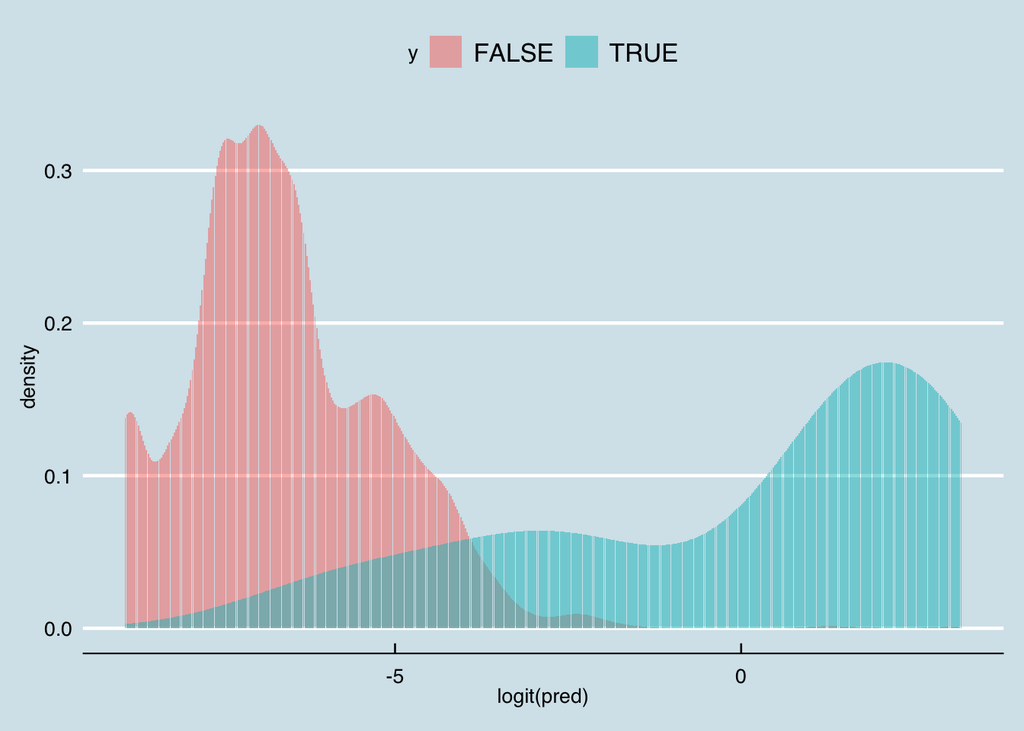

```r
logit <- function(x) log(x / (1 - x))

pred_data = tibble(y = data_valid$outcome == 'dead',
       pred = predict(bst, dvalid_xgb, type='prob'))
pred_data %>%
    ggplot(aes(logit(pred), fill = y)) +
    geom_histogram(stat = 'density', alpha = 0.5, position = 'identity')
```

```r
sigmoid = function(x) 1 / (1 + exp(x))
logit = function(x) log(x / (1 - x))

th = sigmoid(1) * 100
th
```

```
## [1] 26.89414
```

```r
th = 30

lrm_explain = DALEX::explain(lrm, data = data_valid %>% select(-outcome),
                             y = data_valid$outcome == 'dead',
                             type = 'classification', label = 'GLM',
                             predict_function = function(m, d) yhat(m, d) * 100)
```

```
## Preparation of a new explainer is initiated
##   -> model label       :  GLM
##   -> data              :  3507  rows  8  cols
##   -> data              :  tibbble converted into a data.frame
##   -> target variable   :  3507  values
##   -> model_info        :  package stats , ver. 3.6.1 , task regression (  default  )
##   -> model_info        :  type set to  classification
##   -> predict function  :  function(m, d) yhat(m, d) * 100
##   -> predicted values  :  numerical, min =  0.0004510013 , mean =  1.278237 , max =  97.68853
##   -> residual function :  difference between y and yhat (  default  )
##   -> residuals         :  numerical, min =  -97.68853 , mean =  -1.265691 , max =  0.9559789
##   A new explainer has been created!
```

```r
xgb_predict = function(model, data) {
    data = model.matrix(~ . - 1, data = data, xlev = xlevs)
    predict(model, data, type = 'prob') * 100
}
xgb_explain = DALEX::explain(bst, data = data_valid %>% select(-outcome),
                             y = data_valid$outcome == 'dead',
                             type = 'classification', label = 'XGB',
                             predict_function = xgb_predict)
```

```
## Preparation of a new explainer is initiated
##   -> model label       :  XGB
##   -> data              :  3507  rows  8  cols
##   -> data              :  tibbble converted into a data.frame
##   -> target variable   :  3507  values
##   -> model_info        :  package Model of class: xgb.Booster package unrecognized , ver. Unknown , task regression (  default  )
##   -> model_info        :  type set to  classification
##   -> predict function  :  xgb_predict
##   -> predicted values  :  numerical, min =  0.0136907 , mean =  1.27685 , max =  96.00006
##   -> residual function :  difference between y and yhat (  default  )
##   -> residuals         :  numerical, min =  -95.58954 , mean =  -1.264304 , max =  0.8893257
##   A new explainer has been created!
```

```r
glmnet_predict = function(model, data) {
    data = model.matrix(~ age + pos(age, 50) + . - 1, data = data, xlev = xlevs)
    predict(model, data, type = 'response', s = 'lambda.min')[, 1] * 100
}

cv_glmnet_explain = DALEX::explain(cv_glmnet, data = data_valid %>% select(-outcome),
                                    y = data_valid$outcome == 'dead',
                                    type = 'classification', label = 'GLMNET',
                                    predict_function = glmnet_predict)
```

```
## Preparation of a new explainer is initiated
##   -> model label       :  GLMNET
##   -> data              :  3507  rows  8  cols
##   -> data              :  tibbble converted into a data.frame
##   -> target variable   :  3507  values
##   -> model_info        :  package glmnet , ver. 3.0.2 , task regression (  default  )
##   -> model_info        :  type set to  classification
##   -> predict function  :  glmnet_predict
##   -> predicted values  :  numerical, min =  0.000566685 , mean =  1.283465 , max =  97.06777
##   -> residual function :  difference between y and yhat (  default  )
##   -> residuals         :  numerical, min =  -97.06777 , mean =  -1.270919 , max =  0.922466
##   A new explainer has been created!
```

```r
lrm_perf = DALEX::model_performance(lrm_explain, cutoff = th)
xgb_perf = DALEX::model_performance(xgb_explain, cutoff = th)
cv_glmnet_perf = DALEX::model_performance(cv_glmnet_explain, cutoff = th)
lrm_perf
```

```
## Measures for:  classification
## recall   : 0.6590909
## precision: 0.7837838
## f1       : 0.7160494
## accuracy : 0.9934417
## auc      : 0.9651905
##
## Residuals:
##            0%           10%           20%           30%           40%
## -97.688531415  -1.249344824  -0.462650436  -0.217479287  -0.118927458
##           50%           60%           70%           80%           90%
##  -0.067177331  -0.038535940  -0.023348443  -0.013391214  -0.005011146
##          100%
##   0.955978862
```

```r
xgb_perf
```

```
## Measures for:  classification
## recall   : 0.6590909
## precision: 0.8285714
## f1       : 0.7341772
## accuracy : 0.994012
## auc      : 0.9651511
##
## Residuals:
##           0%          10%          20%          30%          40%
## -95.58953643  -1.10506127  -0.52443114  -0.24479215  -0.16270687
##          50%          60%          70%          80%          90%
##  -0.11067431  -0.08978534  -0.05681038  -0.04515557  -0.02407478
##         100%
##   0.88932569
```

```r
cv_glmnet_perf
```

```
## Measures for:  classification
## recall   : 0.6590909
## precision: 0.7837838
## f1       : 0.7160494
## accuracy : 0.9934417
## auc      : 0.9653939
##
## Residuals:
##           0%          10%          20%          30%          40%
## -97.06777076  -1.20006002  -0.49473303  -0.25057742  -0.15334023
##          50%          60%          70%          80%          90%
##  -0.09260178  -0.05901679  -0.03660393  -0.02300946  -0.01034292
##         100%
##   0.92246596
```

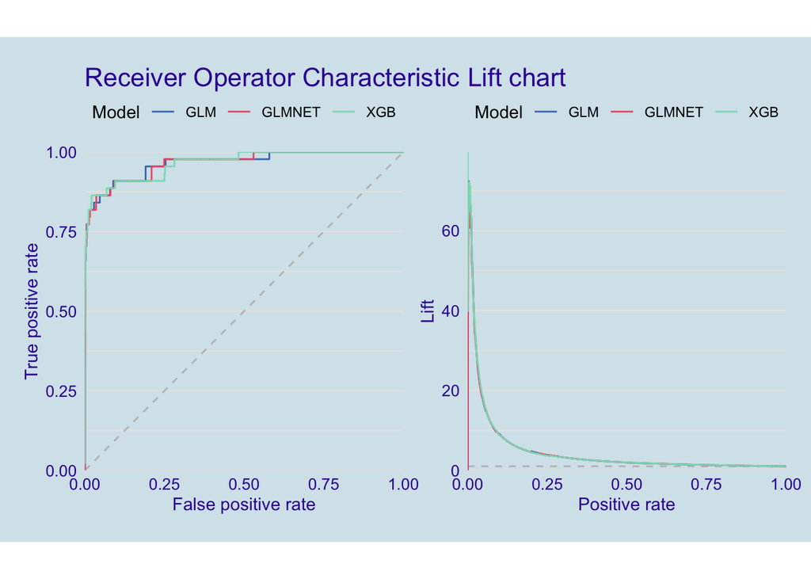

```r
p1 <- plot(cv_glmnet_perf, xgb_perf, lrm_perf, geom = "roc")
p2 <- plot(cv_glmnet_perf, xgb_perf, lrm_perf, geom = "lift")

library(patchwork)
p1 + p2
```

### 2. For some selected observation from this dataset, calculate the model predictions for model (1)

```r
example_ind = 1
example = data_valid[example_ind, ]
example
```

| age | sex | country | chronic_disease | outcome | pneumonia\|pneumonitis | fever | cough | sore throat |
| --- | --- | --- | --- | --- | --- | --- | --- | --- |
| 71 | female | other | unknown | recovered | FALSE | FALSE | FALSE | FALSE |

```r
xgb_predict(bst, example %>% select(-outcome))
```

```
## [1] 0.5650226
```

XGBoost model predicts < 1% mortality rate for a 71 year old woman, without any known symptoms. Seems pretty low, nevertheless it is correct.

### 3. For an observation selected in (2), calculate the decomposition of model prediction using Ceteris paribus / ICE profiles (packages for R: DALEX, ALEPlot, ingredients, packages for python: pyCeterisParibus).

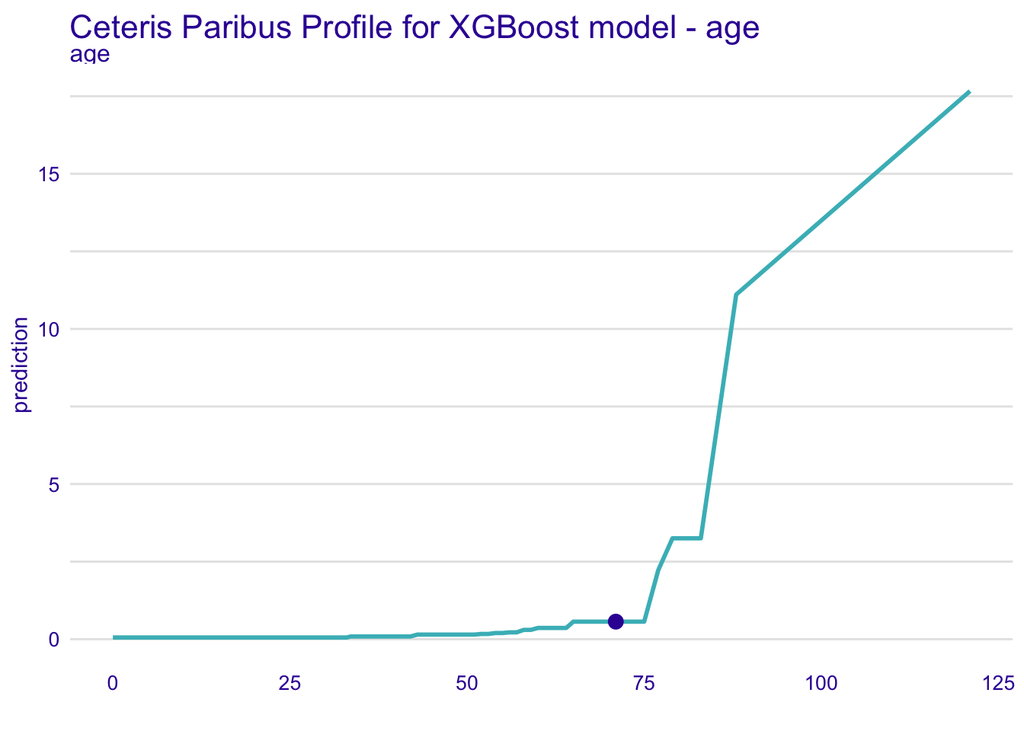

```r
cp_example = DALEX::individual_profile(xgb_explain, example %>% as.data.frame)
plot(cp_example, variables = c('age')) +
    ggtitle('Ceteris Paribus Profile for XGBoost model - age')
```

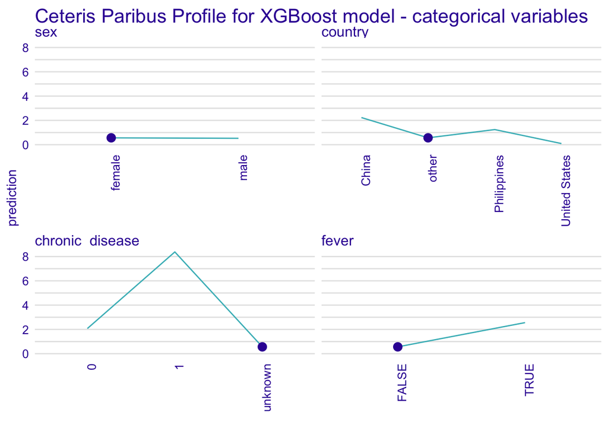

```r
plot(cp_example, variables = c('sex', 'country', 'chronic_disease', 'fever'), variable_type = 'categorical') +
    ggtitle('Ceteris Paribus Profile for XGBoost model - categorical variables')
```

### 4. Find two observations in the data set, such that they have different CP profiles (e.g. model response is growing with age for one observations and lowering with age for another). Note that you need to have model with interactions to have such differences

```r
xgb_preds = xgb_predict(bst, data_valid %>% select(-outcome))
low_examples = c(974, 2525)
med_examples = c(2195, 3313)
high_examples = c(101, 2657)
all_examples = c(low_examples, med_examples, high_examples)
data_valid[c(2525, 2657), ]
```

| age | sex | country | chronic_disease | outcome | pneumonia\|pneumonitis | fever | cough | sore throat |
| --- | --- | --- | --- | --- | --- | --- | --- | --- |
| 26 | female | United States | unknown | recovered | FALSE | FALSE | FALSE | FALSE |
| 82 | female | China | 1 | dead | FALSE | FALSE | FALSE | FALSE |

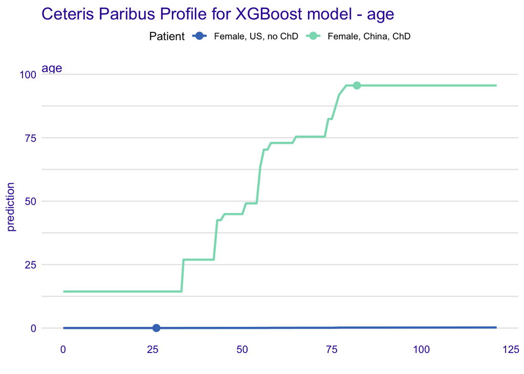

```r
cp_example = DALEX::individual_profile(xgb_explain, data_valid[c(2525, 2657), ] %>% as.data.frame)
plot(cp_example, color = '_ids_',
     variables = c('age')) +
    scale_color_manual(name = "Patient", breaks = 1:2,
                       values = c("#4378bf", "#8bdcbe"),
                       labels = c("Female, US, no ChD" , "Female, China, ChD")) +
    ggtitle('Ceteris Paribus Profile for XGBoost model - age')
```

Here we can see two drastically different CP age profiles.

Although the XGBoost model has monotonicity constraints, the mortality rate for a female person living in United States having no chronic diseases stays basically flat across whole age spectrum, even at a very old age.

On the other hand, a female from China with chronic diseases present, has a very steep age profile, with mortality rate being close to 100% at an old age.

The first profile looks unreasonable, this is probably due to no mortal cases of older people in US having no chronic diseases. Such occurences are probably rare, and given the small positive sample size, no such cases is likely to happen.

### 5. Train a second model (of any class, neural nets, linear, other boosting) and find an observation for which CP profiles are different between the models

```r
data_valid[2657, ]
```

| age | sex | country | chronic_disease | outcome | pneumonia\|pneumonitis | fever | cough | sore throat |
| --- | --- | --- | --- | --- | --- | --- | --- | --- |
| 82 | female | China | 1 | dead | FALSE | FALSE | FALSE | FALSE |

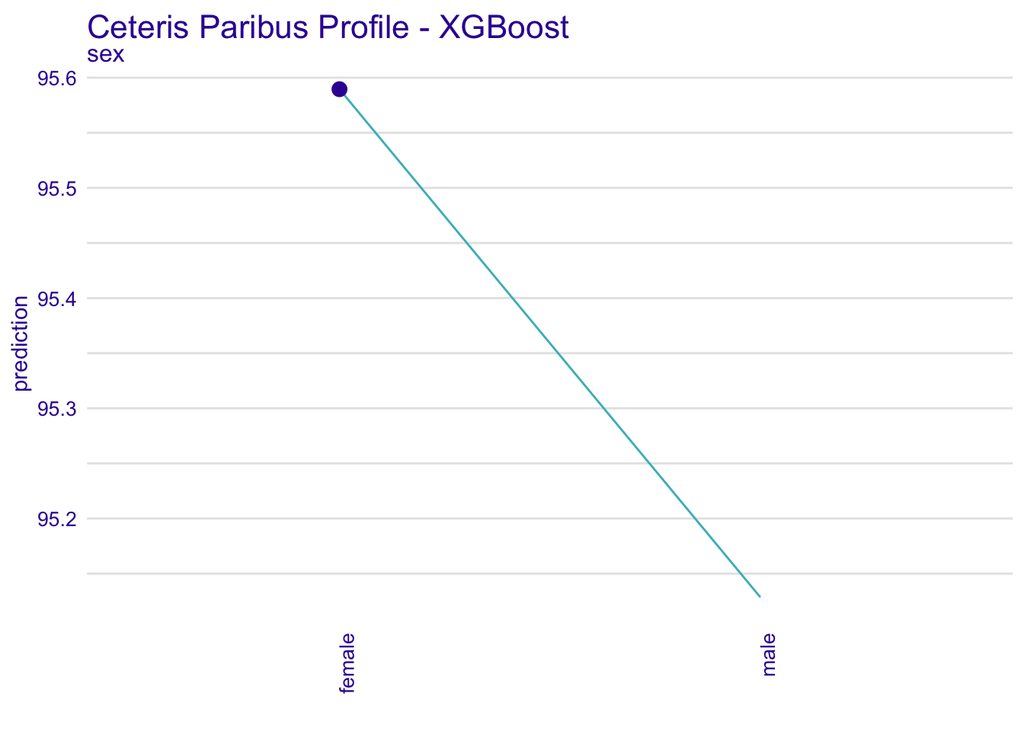

```r
xgb_cp_example = DALEX::individual_profile(xgb_explain, data_valid[2657, ] %>% as.data.frame)

plot(xgb_cp_example,
     variables = c('sex'),
     variable_type = 'categorical') +
     ggtitle("Ceteris Paribus Profile - XGBoost")
```

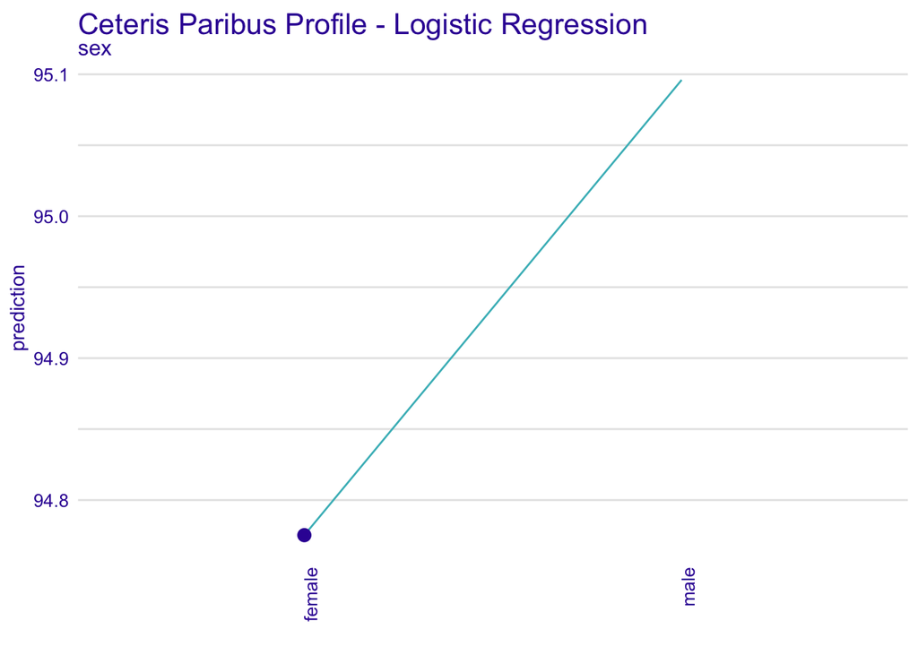

```r
lrm_cp_example = DALEX::individual_profile(lrm_explain, data_valid[2657, ] %>% as.data.frame)

plot(lrm_cp_example,
     variables = c('sex'),
     variable_type = 'categorical') +
     ggtitle("Ceteris Paribus Profile - Logistic Regression")
```

Here we can see gender variable CP profiles for XGBoost and Logistic Regression models.

Due to the additive nature of LR model, the overall higher mortality rate among men yields a positive effect for male indicator variable, which can also be seen above.

However, for XGBoost model, male gender would decrease the mortality rate prediction by around 0.4% This suggests that the effect of gender varies across the observation space and interacts with other variables.